# Lecture_01_Start

코드를 입력하거나 문서를 작성하는 이 위치를 셀(cell)이라고 합니다. 쥬피터 노트북 입력 모드는 Code 모드와 Markdown 모드가 있습니다. 코드 모드는 소스 코드를 작성하고 실행할 수 있는 모드이며 마크다운은 노트북에서 문서를 작성하는 모드입니다. 두 모드간의 변경은 셀 왼쪽의 빈공간을 클릭하여 명령모드로 나간후(셀의 왼쪽이 파란색으로 변경됨) y 키를 누르면 Code 모드, m을 누르면 Markdown 모드로 변경됩니다. 메뉴아래 Code라고 적혀있는 콤보 박스에서도 선택 가능합니다.

아래의 코드를 Code 모드에서 입력후 shift + enter 를 눌러 실행시키면 결과가 출력됩니다.

```python
30 + 10
```

```
40
```

```python
10 / 3
```

```
3.3333333333333335
```

```python
a = 10
b = 20

a + b
```

```
30
```

```python
a = 10
b = 20

a + b
```

```
30
```

```python
5 - 3
```

```
2
```

## 마크다운 사용법

필요한 내용을 정리하기 위해서는 마크다운 모드로 들어갑니다. (메뉴아래 툴 모임에서 code 라고 적혀있는 콤보 박스를 클릭하여 Markdown 선택) 아래의 마크다운 문장들을 작성한후 shift + enter키를 눌러 실행합니다.

# Heading level 1

## Heading level 2

### Heading level 3

###### Heading level 6

마크다운 모드에서 여러줄 입력을 위해서는 중간에 빈줄을 삽입합니다.

마크다운 모드입니다.

두번째 줄을 입력합니다.

두 문장들을 출력하기위해 첫번째 문장을 입력하고 스페이스키 두번 입력후 엔터를 치고 두번째 줄을 입력합니다.

마크다운모드입니다.  
두번째 줄을 입력합니다.

두 문장을 출력하는 다른 방법입니다.

마크다운모드입니다  
두번째 줄을 입력합니다.

강조 문자를 작성하는 방법

**볼드체**를 입력합니다.

**볼드체** 를 입력하는 두번째 방법

이탤리체 문자를 입력하는 방법

The *cat's meow*

볼드 이탤릭은 *** 로 문장을 묶어줍니다.

*Important*

아래문장은 들여쓰기 합니다.

> 들여쓰는 문장

> 들여쓰는 문장 2

중첩된 들여쓰기

> This the first paragraph.

> > And this is the nested paragraph

문장앞에 점기호 추가

- 문장앞에 점기호를 추가합니다.
- 테스트 문자열

리스트 작성법

1. First item
2. Second item
3. Third item
1. First item
2. Second item
3. Third item
1. First item
2. Second item

중첩된 리스트 작성

1. First item
2. Second item
   1. Indented item
   2. Indented item
- First item
- Second item
- Third item
- First item
- Second item
- Third item
- First item
- Second item
- Third itme
- First item
- Second item
  - Indented item
  - Indented item

마크다운 문서안에 코드를 입력하는 경우

파이썬 코드를 넣습니다.

```
a = 10
b = 20
print(a + b)
```

C 언어 코드를 문서에 포함시킵니다.

```
#include <stdio.h>
int main(void)
{
    printf("Hello World!!\n);
}
```

link 추가

Use [Naver](http://naver.com)

문서에 이미지 추가

[figure not shown]

이미지를 복사 붙여넣기 해도 문서에 포함시킬 수 있습니다.

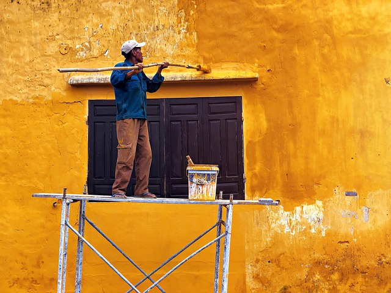

표를 문서에 포함시키는 방법

| Syntax | Description |
| --- | --- |
| Header | Title |
| Paragraph | Text |

# 변수와 기본 타입

변수를 이용하여 문자열을 출력해 봅니다.

프로그램은 message라는 변수를 추가했습니다. 변수는 대입문(=)의 오른쪽에 있는 값과 연결되어 있습니다. 인터프리터(해석기)는 message라는 변수에 "Hello world"라는 텍스트를 연결합니다. print()는 문자열을 화면에 출력하는 기능을 갖는 내장함수(파이썬 안에 포함되어 있음)입니다.

```python
# 주석 : 프로그램에 대한 설명을 작성하기 위한 일종의 메모입니다.
# 파이썬 주석은 # 기호를 입력하여 작성합니다.
# 주석은 프로그램 실행시 기계어로 변환되지 않습니다.

# '=' 등호 기호는 프로그래밍에서는 오른쪽의 값을 왼쪽의 변수에 저장을 하거나 연결 시킵니다.
# = 기호를 대입연산자(assignment)라고 부릅니다.

message = "Hello world!"   # message는 변수입니다.
print(message)

# 우리가 message를 변수라고 부르는 이유는 변수가 가지는 값을 변경 가능하기 때문입니다.
message = "Hello everyone!"
print(message)
```

```
Hello world!
Hello everyone!
```

```python
print(message)
```

[output not shown]

변수의 값은 **언제든지 변경** 가능합니다.

## 변수 이름 짓기

파이썬에서 변수의 이름을 지을때 규칙과 가이드가 있습니다.

- 변수 이름에는 글자(영문자), 숫자, 밑줄만 사용할 수 있습니다. 변수는 글자나 밑줄로 시작할 수 있지만 숫자로는 시작할 수 없습니다.

```python
message_1 = "Hello World"    # 올바른 변수명
```

```python
_message1 = "Hello World"
```

```python
1_message = "Hello"    # 변수명의 시작부에 숫자가 오면 안됩니다.
```

```
  Cell In[29], line 1
    1_message = "Hello"    # 변수명의 시작부에 숫자가 오면 안됩니다.
     ^
SyntaxError: invalid decimal literal
```

- 변수 이름에 빈칸을 사용할 수 없습니다. 대신에 두 단어를 연결해서 하나의 변수로 사용해야 하는 경우에는 밑줄로 구분하여 작성하면됩니다.

```python
greeting_message = "hi everyone!!"
```

- 파이썬에서 특정 목적으로 미리 예약해둔 키워드나 함수 이름을 변수 이름으로 사용할 수 없습니다.

```
**파이썬 키워드**
```

| False | await | else | import | pass |
| --- | --- | --- | --- | --- |
| None | break | except | in | raise |
| True | class | finally | is | return |
| and | continue | for | lambda | try |
| as | def | from | nonlocal | while |
| assert | del | global | not | with |
| async | elis | if | or | yield |

- 변수 이름은 짧으면서도 의미가 있어야 합니다. 예를 들면 n 보다 name 이 좋고, 학생이름을 저장하는 변수는 s_n보다는 student_name이 좋고 length_of_persons_name 보다는 name_length가 좋습니다.
- 소문자 l, 대문자 O를 쓸 때 숫자 1, 0과 혼동하지 않도록 조심합니다.

파이썬의 네이밍 관례상 소문만 사용하는 것이 좋습니다. 변수 이름을 대문자로 사용해도 에러가 발생하지는 않지만 대문자로 작성한 변수명은 특별한 의미(상수 : 프로그램안에서 변경되면 안되는 데이터를 연결할 변수)를 갖습니다.

다음 예제는 고의로 에러를 유발하고 있습니다.

```python
message = "Hello world"

print(mesage)   # s가 누락이 됨(구문 오류)
```

```
---------------------------------------------------------------------------
NameError                                 Traceback (most recent call last)
Cell In[33], line 3
      1 message = "Hello world"
----> 3 print(mesage)

NameError: name 'mesage' is not defined
```

### 기본 데이터 타입(Basic Data Type)

### 문자열 (String)

**문자열** 은 연속된 문자입니다. 파이썬에서 따옴표 안에 있는 것은 문자열로 간주합니다. 다른 언어와 차이점은 파이썬에서 문자열은 큰따옴표나 작은 따옴표 모두 사용할 수 있습니다.

"큰 따옴표로 문자열을 표현합니다"  
'작은 따옴표로 문자열을 표현하는 것도 가능합니다.'

문자열안에 큰 따옴표나 작은 따옴표가 포함된 경우에는 포함되는 문자열을 외부의 기호와 다른 기호를 사용하여 표현합니다.

'I told my friend, "Python is my favorite language."' "The language 'python' is named after Monty Python, not the snake."

```python
message = 'I told my friend, "Python is my favorite language."'
print(message)
```

```
I told my friend, "Python is my favorite language."
```

```python
message = "The language 'python' is named after Monty Python, not the snake."
```

### 문자열 대소문자 바꾸기

```python
# 파이썬은 데이터를 변수에 대입했을 때 변수의 타입이 결정됩니다. (동적 타이핑)
name = "taylor swift"
print(name.title())    # 문자열의 각 단어의 첫글자를 대문자로 출력하는 함수가 title()
```

```
Taylor Swift
```

print() 함수를 호출할 때 변수명 이름 다음에 .을 찍고 title() 메서드를 썼습니다. 메서드는 파이썬이 데이터를 가지고 할 수 있는 일이라고 생각하면됩니다.

```python
type(name)
```

```
str
```

C 언어의 경우는 변수 선언시 타입을 먼저 지정해야 합니다. 파이썬과의 차이점

```
char name[10] = "taylor swift";
```

문자열 전체를 대문자 혹은 소문자로 변경하는 경우. 문자열 클래스의 upper(), lower()를 사용합니다.

```python
name = "taylor swift"
print(name.upper())   # name 변수의 문자열을 대문자로 변경
```

```
TAYLOR SWIFT
```

```python
name = "TAYLOR SWIFT"
print(name.lower())
```

```
taylor swift
```

### 문자열 안에서 변수 사용

때로는 문자열 안에 변수 값을 써야 할 때도 있습니다. 예를 들어 변수 하나는 이름, 다른 변수는 성을 각각 지정하여 이들을 합쳐서 전체 이름으로 사용할 수 있습니다.

```python
first_name = "taylor"
last_name = "swift"

full_name = f"{first_name} {last_name}"
print(full_name)
```

```
taylor swift
```

이런 문자열을 f-문자열이라고 부릅니다. 여기서 f는 format, 즉 형식을 갖춘다는 의미입니다.

f-문자열을 써서 메시지를 조합하고, 전체 메시지를 다시 변수에 할당할 수도 있습니다.

```python
first_name = "taylor"
last_name = "swift"
full_name = f"{first_name} {last_name}"

message = f"Hello, {full_name.title()}!"
print(message)
```

```
Hello, Taylor Swift!
```

f-문자열은 파이썬 3.6에서 도입되었으므로 그 이상 버전에서만 사용할 수 있습니다.

이전에 사용하던 방식

```python
first_name = "taylor"
last_name = "swift"
full_name = "{} {}".format(first_name, last_name)

print(full_name)
```

```
taylor swift
```

### 탭이나 줄바꿈 문자를 써서 문자열에 공백 추가(이스케이프 시퀀스(탈출문자)라고 부릅니다.)

프로그램에서 공백은 스페이스, 탭, 줄바꿈 기호처럼 화면에 표시되지 않는 문자를 가리킵니다. 공백은 보통 출력 결과를 일정한 형식으로 정리해서 사용자가 읽기 쉽게 만들 때 사용합니다.

문자열안에 탭(tap)을 추가하려면 다음과 같이 \t를 사용합니다.

```python
print("Python")
```

```
Python
```

```python
print("\tPython")
```

```
	Python
```

문자열에 줄바꿈을 추가하려면 다음과 같이 줄바꿈 문자(개행문자: newline) \n를 사용합니다.

```python
print("Languages:\nPython\nC\nJavaScript")
```

```
Languages:
Python
C
JavaScript
```

하나의 문자열에 탭과 줄바꿈 문자를 조합해서 사용할 수 있습니다. 문자열 "\n\t"는 먼저 줄을 바꾼후 탭을 넣으라는 의미입니다.

```python
print("Languages:\n\tPython\n\tC\n\tJavaScript")
```

```
Languages:
	Python
	C
	JavaScript
```

### 문자열 안의 공백 제거

두 문자열을 비교해서 둘이 같은 문자열인지 확인해야 할 때가 많습니다. 예를 들어 웹사이트에 로그인하면서 이름을 입력하는 경우가 있습니다. 사용자가 입력하는 데이터는 공백이 포함되어 있는 경우가 있으며 이 경우 공백을 제거하는 쉬운 방법이 있습니다.

파이썬은 문자열의 오른쪽과 왼쪽 공백을 찾을 수 있습니다. 문자열의 오른쪽에 있는 공백을 모두 제거할 때는 문자열 클래스의 rstrip()메서드를 사용합니다.(rstrip() : right strip())

```python
favorite_language = 'python '
favorite_language
```

```
'python '
```

```python
favorite_language.rstrip()   # 원본은 변경하지 않습니다.
```

```
'python'
```

```python
favorite_language
```

```
'python '
```

```python
# 만약에 공백이 제거된 문자열이 프로그램 내부에서 필요한 경우 변수에 저장을 해야 합니다.
stripped_string = favorite_language.rstrip()
```

```python
stripped_string
```

```
'python'
```

```python
favorite_language
```

```
'python '
```

```python
favorite_language = favorite_language.rstrip()
```

```python
favorite_language
```

```
'python'
```

### 문자열의 왼쪽 공백들을 제거하려면 문자열 클래스의 lstrip() 메서드를 사용합니다.

```python
favorite_language = '          Python'
favorite_language.lstrip()
```

```
'Python'
```

```python
favorite_language
```

```
'          Python'
```

### 왼쪽과 오른쪽에 모두 공백이 있는 경우 이를 제거하기 위해서는 strip()를 사용합니다.

```python
favorite_language = '          Python              '
favorite_language.strip()
```

```
'Python'
```

## 숫자형 데이터

숫자는 게임에서 점수를 저장하고, 시각화에서 데이터를 표현하고, 웹 애플리케이션에서 정보를 저장하는 등 사용하는 곳이 많습니다. 먼저 정수를 어떻게 다루는지 알아보겠습니다.

### 정수

파이썬에서는 정수에 대해 산술 연산이 가능합니다.

```python
2 + 3
```

```
5
```

```python
5 - 2
```

```
3
```

```python
3 * 4     # 프로그래밍에서 곱셈은 asterisk 기호(*)를 사용합니다.
```

```
12
```

```python
5 / 8     # 나눗셈은 / 를 사용합니다.
```

```
0.625
```

```python
7 // 3    # 나눈 결과 정수만 취하고 싶으면 // 연산자를 사용합니다.
```

```
2
```

```python
7 % 3     # 나눈 결과 나머지를 구하고 싶으면 % 연산자를 사용
```

```
1
```

파이썬에서 지수를 계산할 때는 *기호를 두 개 사용합니다.

```python
3 ** 2
```

```
9
```

파이썬은 계산 우선순위(연산하는 순서)를 지원하며 괄호를 써서 계산 순서를 바꾸는 게 가능합니다.

```python
2 + 3 * 4
```

```
14
```

```python
(2 + 3) * 4
```

```
20
```

### 부동소수점 숫자

소수점이 있는 숫자를 부동소수점<sup>floating point number</sup> 숫자라고 부릅니다. 소수점이 숫자 어디서든 떠다닌다는 의미입니다.

```python
0.1 + 0.1
```

```
0.2
```

```python
2 * 0.1
```

```
0.2
```

컴퓨터가 부동소수점수를 저장하는 방식으로 인해 때로는 이상한 결과가 나올 수도 있습니다.

```python
0.2 + 0.1
```

```
0.30000000000000004
```

```python
3 * 0.1
```

```
0.30000000000000004
```

### 정수와 부동소수점 숫자

파이썬에서 나눗셈을 하면 항상 부동소수점 숫자로 표현됩니다.

```python
4 / 2
```

```
2.0
```

나눗셈 이외의 다른 계산에서 정수와 부동소수점 숫자를 섞어 쓰면 결과는 부동소수점 숫자입니다.

```python
1 + 2.0
```

```
3.0
```

```python
2 * 3.0
```

```
6.0
```

### 숫자와 밑줄

아주 큰 숫자를 쓸 때, 다음과 같이 필요한 만큼 자릿수를 나눠서 각 자리를 밑줄로 구분할 수 있습니다. (파이썬 버전 3.6이상만 지원)

```python
universe_age = 14_000_000_000

print(universe_age)
```

```
14000000000
```

### 다중 할당

```python
x, y, z = 0, 0, 0
```

```python
print(x, y, z)
```

```
0 0 0
```

### 상수 (constant number)

```
: 값을 변경할 수 없는 변수
```

상수는 프로그램이 동작하는 동안 값이 바뀌지 않는 변수입니다. 파이썬에는 따로 상수가 존재하지 않으므로 프로그래머들은 상수를 선언할 때 다음과 같이 글자 전부를 대문자로 표기하도록 약속했습니다.

```python
MAX_CONNECTIONS = 5000
```

```python
print(MAX_CONNECTIONS)
```

```
5000
```

```python
MAX_CONNECTIONS = 3000
print(MAX_CONNECTIONS)
```

```
3000
```